# Embryo protein quantification for bottom-up proteomics sample solution digests

Andrew Garcia (CUNY Graduate Center; New York State Institute for Basic Research)

Last compiled on 16 January, 2024 12:39

# Overview

We are testing which protein digestion method to use for the preparation of bottom-up proteomics samples from mutant mouse embryos on the C57BL/6J background that lack Naa10 and Naa12.

Total protein is quantified after tissue lysis and homogenization. We had used the Bradford assay using Advanced Protein Assay PrecisionRed reagent (Cytoskeleton Inc., #ADV02). However, SDS interferes with the Bradford assay even when diluted to a concentration of 5%.

We then switched to the bicinchoninic acid assay (BCA), specifically the micro BCA assay (Thermo, #23235). This allows us to quantify SDS-containing lysis buffers.

# aggregated data for whole embryo lysates

```r
emb.all <- read.csv("https://docs.google.com/spreadsheets/d/e/2PACX-1vTElQBIq1HxfNIbB98zeaF2Blsx8_4MPQhdM4njwJiX6tS7EovpZa4ZL2KhFNPWADiVsVJOT4Jj29MN/pub?gid=0&single=true&output=csv", header = T)

emb.all$sample.type<- as.factor(emb.all$sample.type)
emb.all$Theiler.stage<- as.factor(emb.all$Theiler.stage)
emb.all$digestion.method<- as.factor(emb.all$digestion.method)
emb.all$experiment <-as.factor(emb.all$experiment)


emb.all
```

```
##               sample.ID             sample.type digestion.method
## 1              C57M26-1         C57BL/6J embryo         Rapigest
## 2              C57M26-2         C57BL/6J embryo         Rapigest
## 3              C57M26-3         C57BL/6J embryo         Rapigest
## 4              C57M15-2         C57BL/6J embryo         Rapigest
## 5              C57M15-3         C57BL/6J embryo         Rapigest
## 6              C57M10-7         C57BL/6J embryo         Rapigest
## 7              C57M10-8         C57BL/6J embryo         Rapigest
## 8              C57M10-5         C57BL/6J embryo         Rapigest
## 9              C57M10-6         C57BL/6J embryo         Rapigest
## 10        R1-2023-06-23         C57BL/6J embryo         Rapigest
## 11        R2-2023-06-23          11-protein mix         Rapigest
## 12        R3-2023-06-25         C57BL/6J embryo         Rapigest
## 13        R4-2023-06-25         C57BL/6J embryo         Rapigest
## 14        R5-2023-06-25         C57BL/6J embryo         Rapigest
## 15        R6-2023-06-25          11-protein mix         Rapigest
## 16        S2-2023-06-25 11-protein mix (S-trap)           S-trap
## 17 C57M-37-1-2023-10-05         C57BL/6J embryo           S-trap
## 18 C57M-37-3-2023-10-05         C57BL/6J embryo           S-trap
## 19 C57M-37-4-2023-10-05         C57BL/6J embryo           S-trap
## 20    11-mix-2023-10-05          11-protein mix           S-trap
## 21            C57M-37-5         C57BL/6J embryo           S-trap
## 22            C57M-38-1         C57BL/6J embryo           S-trap
## 23            C57M-38-3         C57BL/6J embryo           S-trap
## 24                12B-4         C57BL/6J embryo           S-trap
## 25                12B-6         C57BL/6J embryo           S-trap
## 26             C57M15-2         C57BL/6J embryo         Rapigest
## 27             C57M15-3         C57BL/6J embryo         Rapigest
## 28             C57M26-1         C57BL/6J embryo         Rapigest
## 29             C57M26-2         C57BL/6J embryo         Rapigest
## 30             C57M26-3         C57BL/6J embryo         Rapigest
## 31             C57M10-5         C57BL/6J embryo         Rapigest
## 32             C57M10-6         C57BL/6J embryo         Rapigest
## 33        R1-2023-06-23         C57BL/6J embryo         Rapigest
## 34        R2-2023-06-23       protein standards         Rapigest
## 35        R3-2023-06-25         C57BL/6J embryo         Rapigest
## 36        R4-2023-06-25         C57BL/6J embryo         Rapigest
## 37        R5-2023-06-25         C57BL/6J embryo         Rapigest
## 38        R6-2023-06-25       protein standards         Rapigest
## 39        S2-2023-06-25       protein standards           S-trap
```

[output cut: 107 more lines]

```
## 39
## 40
## 41 no photo; may exclude
## 42
## 43
## 44
## 45
## 46
## 47
## 48
## 49
## 50
## 51
## 52
## 53
```

## Summary statistics of total protein via BCA or Bradford

### Grouped by Theiler stage only

```r
library(Rmisc)
#Theiler stage and total protein summary stats
emb_sum <- summarySE(emb.all, measurevar="total.protein",
                     groupvars=c("Theiler.stage"),na.rm = T)
write.csv(emb_sum,"emb_sum.csv")
emb_sum
```

```
##    Theiler.stage  N total.protein        sd        se       ci
## 1                 0           NaN        NA        NA       NA
## 2 11-protein mix  6     169.39600  30.22783 12.340460 31.72216
## 3    TS13 (E8.5) 14      33.50407  31.07351  8.304744 17.94131
## 4    TS15 (E9.5) 18     109.74183  78.71179 18.552546 39.14245
## 5   TS17 (E10.5) 12     414.95975 138.59153 40.007929 88.05686
```

### Grouped by digestion method and Theiler stage

```r
#summary statistics of total protein with both Theiler stage and digestion method
library(Rmisc)
dig_sum <- summarySE(emb.all, measurevar = "total.protein",
                     groupvars = c("digestion.method","Theiler.stage"),
                     na.rm = T)
write.csv(dig_sum, "dig_sum.csv", row.names = F)

dig_sum
```

```
##   digestion.method  Theiler.stage  N total.protein        sd        se
## 1         Rapigest                 0           NaN        NA        NA
## 2         Rapigest 11-protein mix  4     152.71500  15.60732  7.803658
## 3         Rapigest    TS13 (E8.5)  6      44.95500  19.62151  8.010448
## 4         Rapigest    TS15 (E9.5)  8      45.23625  17.62329  6.230774
## 5         Rapigest   TS17 (E10.5)  8     459.28500  93.07123 32.905651
## 6           S-trap 11-protein mix  2     202.75800  22.33326 15.792000
## 7           S-trap    TS13 (E8.5)  8      24.91587  36.35244 12.852528
## 8           S-trap    TS15 (E9.5) 10     161.34630  69.30788 21.917075
## 9           S-trap   TS17 (E10.5)  4     326.30925 185.73681 92.868405
##          ci
## 1        NA
## 2  24.83472
## 3  20.59151
## 4  14.73344
## 5  77.80950
## 6 200.65639
## 7  30.39140
## 8  49.57987
## 9 295.54871
```

Total protein detected at each Theiler stage/digestion method combo.

## experiment effects on total protein detected at each TS

```r
library(Rmisc)
exp_sum <- summarySE(emb.all, measurevar = "total.protein",
                     groupvars = c("digestion.method","quantification.assay","Theiler.stage","experiment"),
                     na.rm = T)
write.csv(exp_sum, "exp_sum.csv", row.names = F)

exp_sum
```

```
##    digestion.method quantification.assay  Theiler.stage experiment N
## 1          Rapigest                  BCA                         1 0
## 2          Rapigest                  BCA 11-protein mix          1 2
## 3          Rapigest                  BCA    TS13 (E8.5)          1 3
## 4          Rapigest                  BCA    TS15 (E9.5)          1 3
## 5          Rapigest                  BCA   TS17 (E10.5)          1 4
## 6          Rapigest             Bradford 11-protein mix          1 2
## 7          Rapigest             Bradford    TS13 (E8.5)          1 3
## 8          Rapigest             Bradford    TS15 (E9.5)          1 5
## 9          Rapigest             Bradford   TS17 (E10.5)          1 4
## 10           S-trap                  BCA 11-protein mix          1 1
## 11           S-trap                  BCA 11-protein mix          2 1
## 12           S-trap                  BCA    TS13 (E8.5)          2 3
## 13           S-trap                  BCA    TS13 (E8.5)          3 2
## 14           S-trap                  BCA    TS13 (E8.5)          5 3
```

[output cut: 27 more lines]

### Linear model of factors that affect total protein

```r
install.packages("car",repos = 'http://cran.us.r-project.org')
```

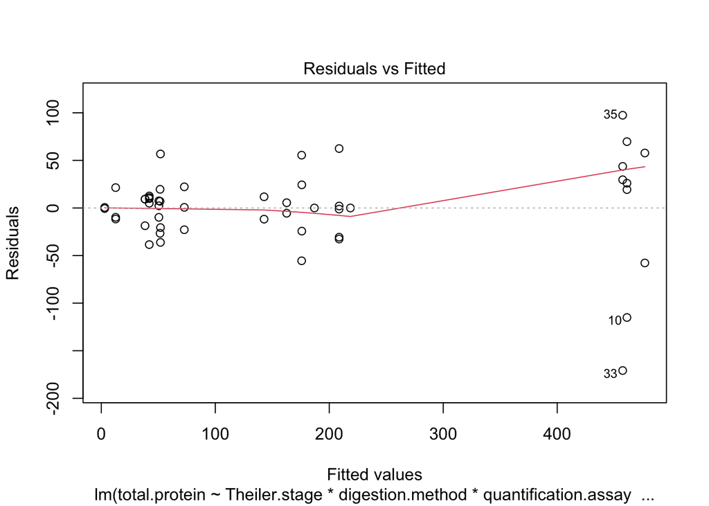

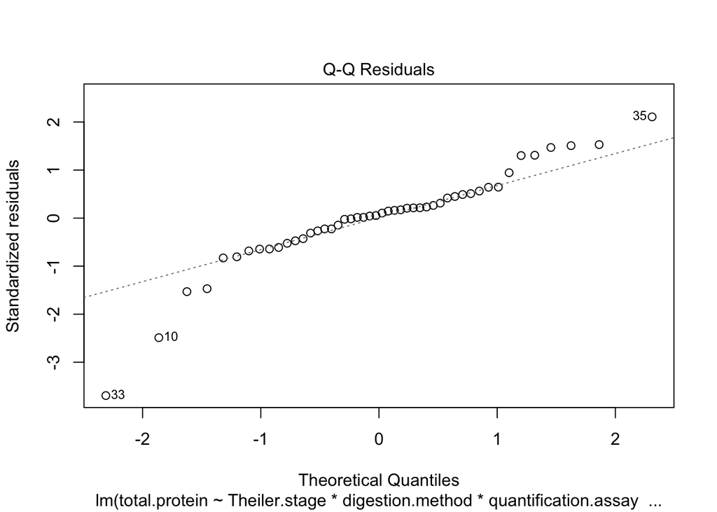

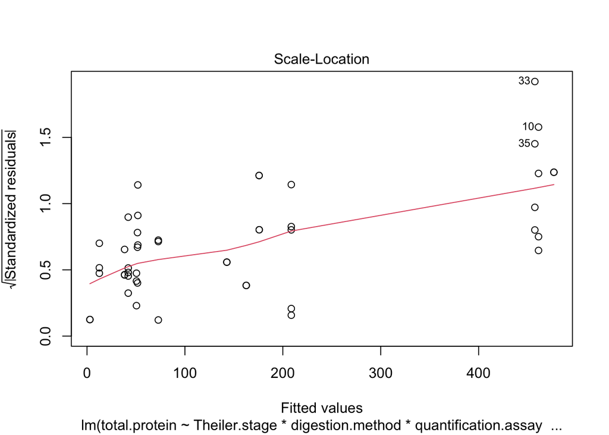

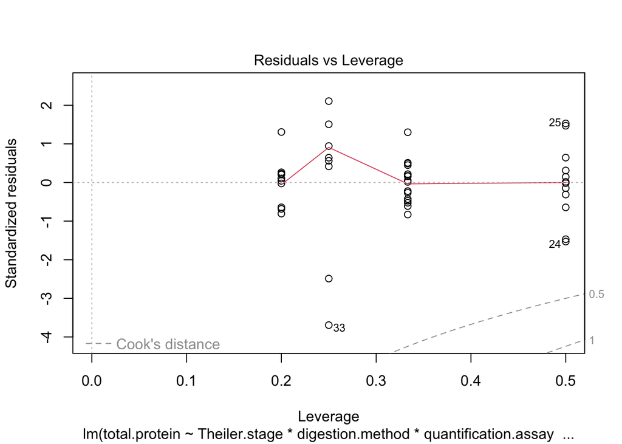

```r
protein.lm <- lm(total.protein ~ Theiler.stage*digestion.method*quantification.assay*experiment,
                 data = emb.all)

plot(protein.lm)
```

What is driving differences in total protein in whole embryo lysate over different Theiler stages?

Do digestion method and quantification assay also affect these?

### Hypotheses

Null hypothesis: there is no difference in total protein between embryos of different ages, digestion methods, and quantification assay.

Alternative hypothesis: there is a difference in total protein due to the aforementioned factors

#### First model

```r
library(car)
summary.aov(protein.lm)
```

```
##                                    Df  Sum Sq Mean Sq F value   Pr(>F)
## Theiler.stage                       3 1046189  348730 122.313  < 2e-16 ***
## digestion.method                    1    2142    2142   0.751    0.393
## quantification.assay                1    1716    1716   0.602    0.444
## experiment                          4    9582    2395   0.840    0.510
## Theiler.stage:digestion.method      3  104057   34686  12.166 1.78e-05 ***
## Theiler.stage:quantification.assay  3     455     152   0.053    0.984
## Theiler.stage:experiment            2  124541   62270  21.841 1.04e-06 ***
## Residuals                          32   91236    2851
## ---
## Signif. codes:  0 '***' 0.001 '**' 0.01 '*' 0.05 '.' 0.1 ' ' 1
## 3 observations deleted due to missingness
```

Embryonic age determined by Theiler staging drives the variation in total protein.

Further, digestion method and quantification assay by themselves do not affect total protein levels.

Theiler stage and digestion method interact, indicating the relationship between total protein detected and Theiler stage depends on digestion method.

2023-10-17: I used a new Benzonase nuclease during this experiment. Lysates were less viscous; will need to compare effects on total protein quantification as well as downstream analyses by David Bolton. May be marginal differences, so more secondary test.

Also I was late to getting the ELISA plate out of incubation or let it cool too long at RT.

I will repeat the BCA assay with these samples later or tomorrow (2023-10-18).

I repeated the BCA assay with these samples 2023-10-18-1150h and replaced the germane data in the aggregated analysis.

I am getting quite variable results for S-trap at E8.5 and E10.5.

I attempted Type III Anova, but there is colinearity between at least 2 variables.

##### post hoc testing

Therefore, I set up an alternative model as below:

#### Alternative model

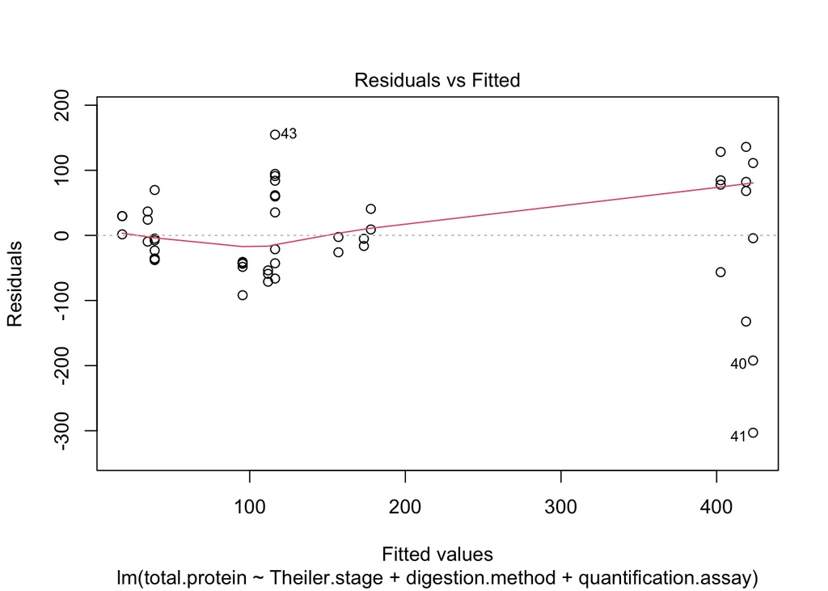

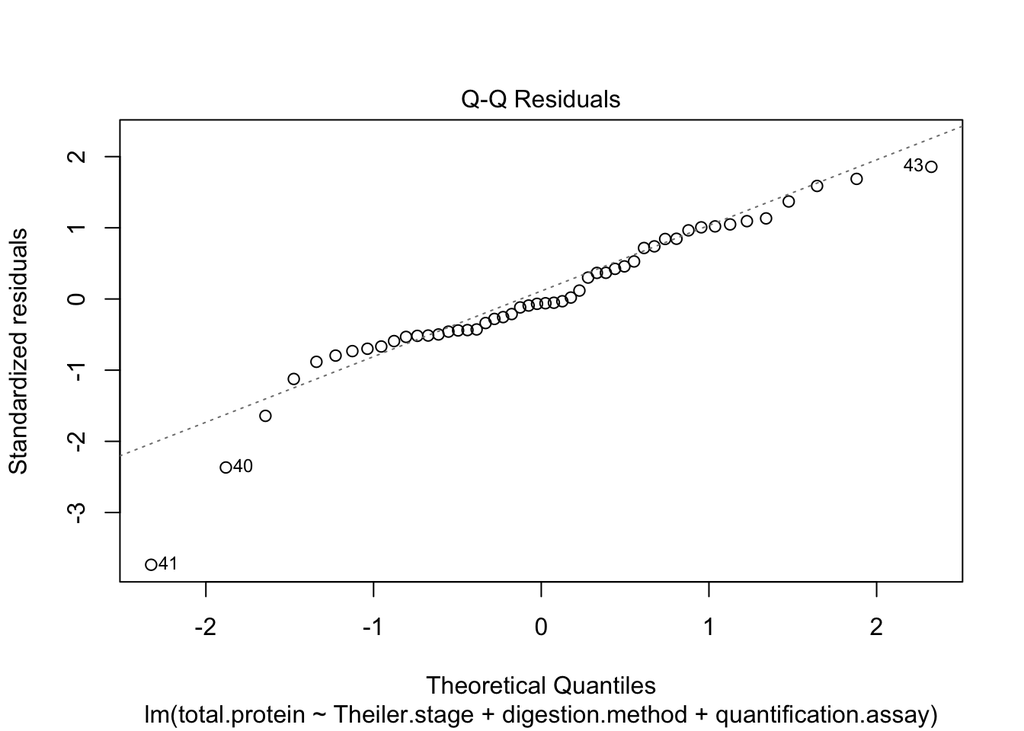

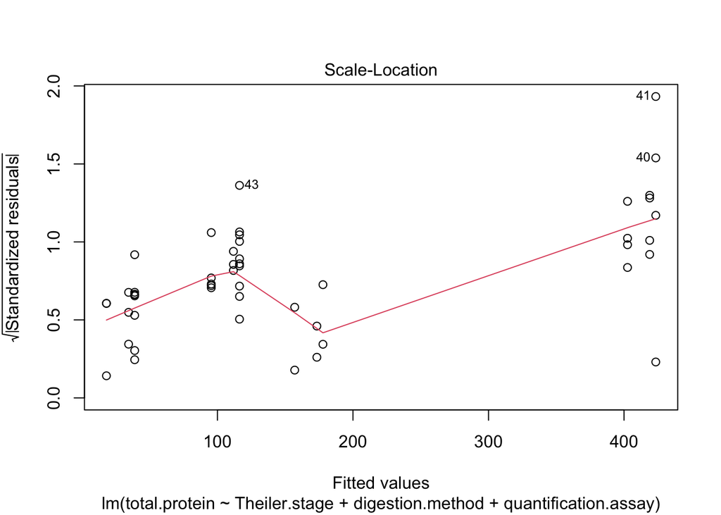

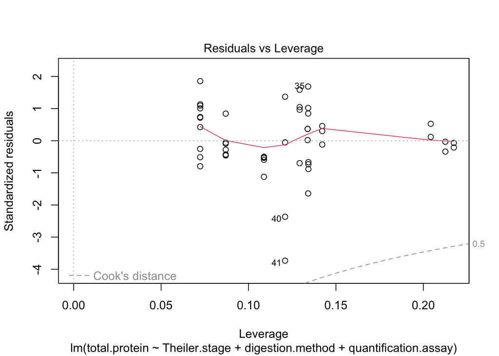

```r
library(car)

proteinalt.lm <- lm(total.protein~Theiler.stage+digestion.method+quantification.assay, data = emb.all)

plot(proteinalt.lm)
```

```r
summary(proteinalt.lm)
```

```
##
## Call:
## lm(formula = total.protein ~ Theiler.stage + digestion.method +
##     quantification.assay, data = emb.all)
##
## Residuals:
##      Min       1Q   Median       3Q      Max
## -303.130  -41.941   -5.075   61.181  154.817
##
## Coefficients:
##                              Estimate Std. Error t value Pr(>|t|)
## (Intercept)                    173.35      40.38   4.293 9.53e-05 ***
## Theiler.stageTS13 (E8.5)      -138.91      42.67  -3.255  0.00218 **
## Theiler.stageTS15 (E9.5)       -61.56      41.26  -1.492  0.14282
## Theiler.stageTS17 (E10.5)      245.56      43.29   5.672 1.02e-06 ***
## digestion.methodS-trap           4.49      31.32   0.143  0.88665
## quantification.assayBradford   -16.35      34.18  -0.478  0.63471
## ---
## Signif. codes:  0 '***' 0.001 '**' 0.01 '*' 0.05 '.' 0.1 ' ' 1
##
## Residual standard error: 86.59 on 44 degrees of freedom
##   (3 observations deleted due to missingness)
## Multiple R-squared:  0.7609, Adjusted R-squared:  0.7338
## F-statistic: 28.01 on 5 and 44 DF,  p-value: 1.212e-12
```

```r
Anova(proteinalt.lm, type = "III")
```

```
## Anova Table (Type III tests)
##
## Response: total.protein
##                       Sum Sq Df F value    Pr(>F)
## (Intercept)           138198  1 18.4336 9.531e-05 ***
## Theiler.stage        1022033  3 45.4414 1.570e-13 ***
## digestion.method         154  1  0.0206    0.8867
## quantification.assay    1716  1  0.2289    0.6347
## Residuals             329871 44
## ---
## Signif. codes:  0 '***' 0.001 '**' 0.01 '*' 0.05 '.' 0.1 ' ' 1
```

#### Model esults

Theiler stage, a morphological proxy for embryonic age, is the primary driver for differences in total protein quantification of single embryo samples.

## Plotting of total protein and Theiler stage

Paired box plot and data points classified by digestion method.

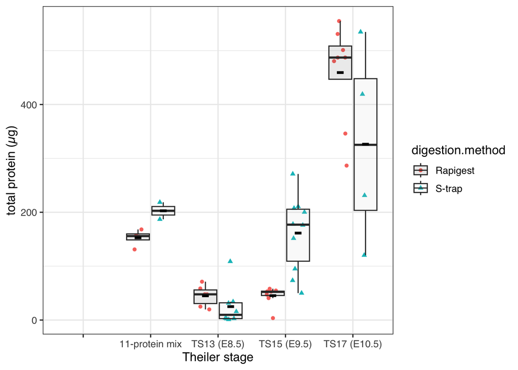

```r
library(ggplot2)
paired.prot.plot <- ggplot(data = emb.all, aes(x = Theiler.stage,
                                               y = total.protein,
                                               fill = digestion.method))+
  geom_point(aes(shape = digestion.method,
                 color = digestion.method),
             position = position_jitterdodge(), alpha=1)+
  geom_boxplot(outlier.shape = NA,
               alpha = 0.1)+
  stat_summary(fun = mean, color = "black", position = position_dodge(0.75),
               width = 0.2,
               geom = "crossbar",
               show.legend = FALSE)+
  xlab("Theiler stage")+
  ylab("total protein (µg)")+
  scale_colour_discrete(na.translate = F)+
  theme_bw(base_size = 12, base_family = "Helvetica")+scale_fill_grey()

paired.prot.plot
```

### Experiment effects?

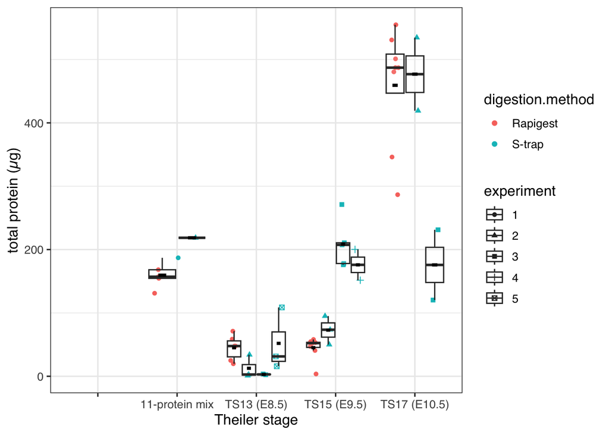

```r
library(ggplot2)
ts.exp.plot <- ggplot(data = emb.all, aes(x = Theiler.stage,
                                               y = total.protein,
                                               shape = experiment))+
  geom_point(aes(color = digestion.method ),
             position = position_jitterdodge(), alpha=1)+
  geom_boxplot(outlier.shape = NA,
               alpha = 0.1)+
  stat_summary(fun = mean, color = "black", position = position_dodge(0.75),
               width = 0.2,
               geom = "crossbar",
               show.legend = FALSE)+
  xlab("Theiler stage")+
  ylab("total protein (µg)")+
  scale_colour_discrete(na.translate = F)+
  theme_bw(base_size = 12, base_family = "Helvetica")+scale_fill_grey()

ts.exp.plot
```

Total protein yields have varied with experiment; getting better at TS15 embryos, but varied with TS17 embryos. S-trap digested TS13 embryos may need to be processed with the S-trap mini column.

## Data points further classified by quantification assay and digestion method.

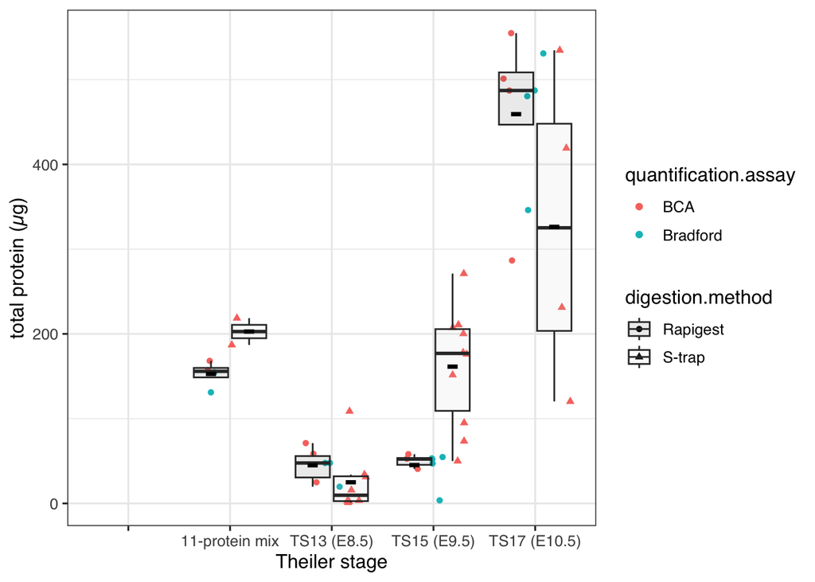

```r
library(ggplot2)
ggplot(data = emb.all, aes(x = Theiler.stage,
                           y = total.protein,
                           fill = digestion.method))+
  geom_point(aes(shape = digestion.method,
                 color = quantification.assay),
             position = position_jitterdodge(), alpha=1)+
  geom_boxplot(outlier.shape = NA,
               alpha = 0.1)+
  stat_summary(fun = mean, color = "black", position = position_dodge(0.75),width = 0.2,
               geom = "crossbar",
               show.legend = FALSE)+
  xlab("Theiler stage")+
  ylab("total protein (µg)")+
  scale_colour_discrete(na.translate = F)+
  theme_bw(base_size = 12, base_family = "Helvetica")+scale_fill_grey()
```

## Total protein and Theiler stage relationship; no other factors

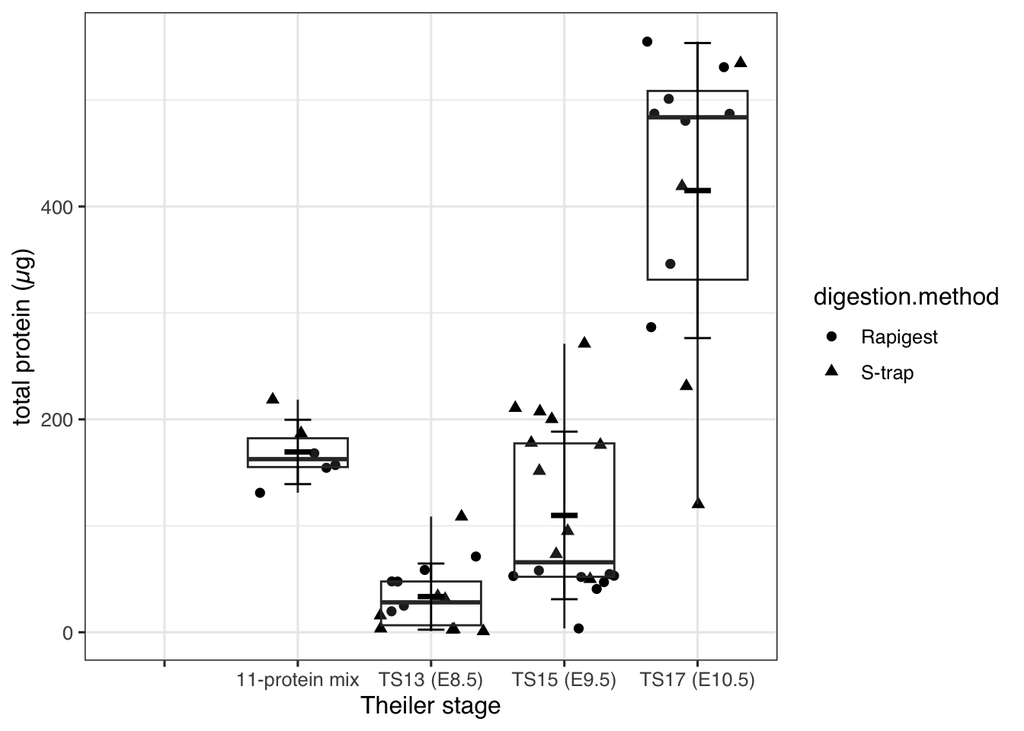

```r
library(ggplot2)

emb.prot.plot <- ggplot(data = emb.all, aes(x = Theiler.stage,
                                            y = total.protein))+
  geom_jitter(aes(shape = digestion.method),
              alpha = 2.0,
              size = 2)+
  geom_boxplot(outlier.shape = NA,
               alpha = 0.1)+
  stat_summary(fun = mean, color = "black", position = position_dodge(0.75),width = 0.2,
               geom = "crossbar",
               show.legend = FALSE)+
  geom_errorbar(data = emb_sum, aes(ymin=total.protein-sd,
                                    ymax=total.protein+sd),
                width=.2,
                position=position_dodge(0.75))+
  xlab("Theiler stage")+
  ylab("total protein (µg)")+
  scale_colour_discrete(na.translate = F)+
  theme_bw(base_size = 12, base_family = "Helvetica")+scale_fill_grey()

emb.prot.plot
```

## Total protein vs digestion method

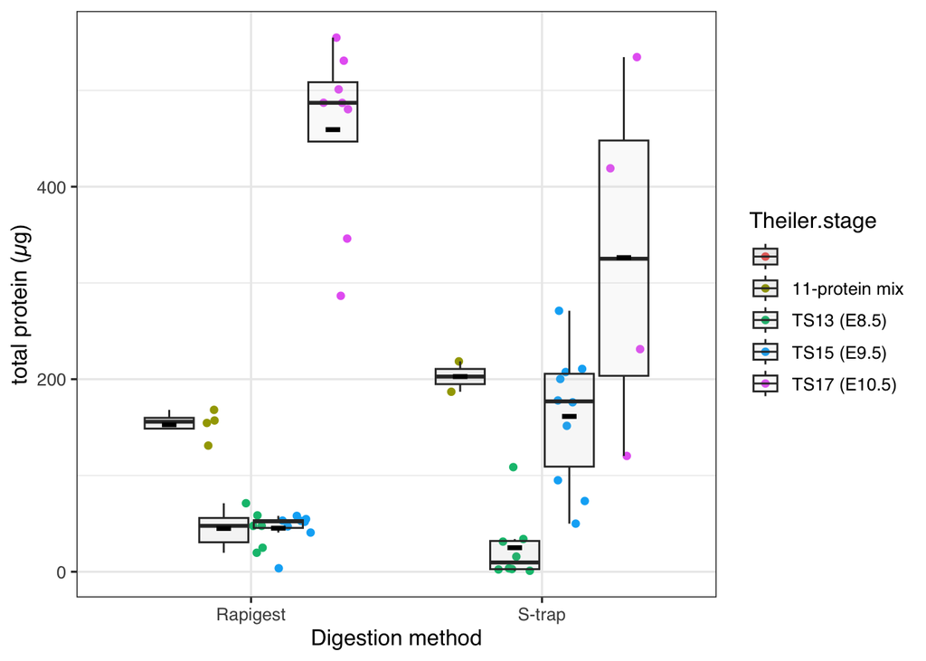

```r
dig.prot.plot <- ggplot(data = emb.all, aes(x = digestion.method,
                                               y = total.protein,
                                               fill = Theiler.stage))+
  geom_point(aes(color = Theiler.stage),
             position = position_jitterdodge(), alpha=1)+
  geom_boxplot(outlier.shape = NA,
               alpha = 0.1)+
  stat_summary(fun = mean, color = "black", position = position_dodge(0.75),
               width = 0.2,
               geom = "crossbar",
               show.legend = FALSE)+
  xlab("Digestion method")+
  ylab("total protein (µg)")+
  scale_colour_discrete(na.translate = F)+
  theme_bw(base_size = 12, base_family = "Helvetica")+scale_fill_grey()

dig.prot.plot
```

### NB5-107-2023-10-17

Big picture wise, both digestion methods extract appreciable amounts of protein to digest with endoproteases to prepare peptide samples for LC-MS.

Both digestion methods seem reasonable. Preference for either will come down to cost or peptides/proteins/Nt-proteins/Nt terminal-peptides oobtained as determined by analysis in PLGS/QIP.

S-trap at this point seems more variable at TS13 and TS17 embryos; I will need to re-run NB5-107-2023-10-17 samples.

I will also do an additional comparison between BCA and Bradford assay using BSA standards. I recapitulated protein levels from my first Rapigest-lysed embryo samples, but want to make sure absorbance/protein readings between both are relatively correlated. First impression is that both produce comparable calibration curves with a protein standard (bovine serum albumin; BSA).

### NB5-107-2023-10-18

Data from NB5-107-2023-10-17 in the aggregated dataset was replaced with data from NB5-107-2023-10-18 data.

Again, both digestion methods seem reasonable for bottom-up proteomics sample preparation from single embryo samples from TS13 through TS17. I.e., we are able to obtain appreciable amounts of protein to digest with endoproteases to prepare bottom-up proteomics samples.

If cost becomes a conern, my hunch is that Rapigest surfactant will be a price constraint while using less trypsin whereas in the S-trap method, the price of trypsin will be a constraint (ie, 1 vial of trypsin per embryo digest); we can make 2X SDS lysis buffer (10% w/v SDS, 100 mM TEAB in LC-MS water). I need to calculate the cost tradeoff per solution digest (≤ 6 TSs; ≤ 6 embryos in each of the 4 genotypes).

Strategically, I will continue estimating TS13 through TS17 embryos as approximately 10 µL droplets for solution digests.

From TS18 onward, I can more easily handle such embryos for weighing to prepare a 10% w/v homogenated lysate. Starting this week, more animals that would otherwise be euthanized will be ready for timed matings to obtain these older whole embryo lysates.

## Alternative plotting?

```r
install.packages("ggbeeswarm", repos ='http://cran.us.r-project.org')
library(ggbeeswarm)
```

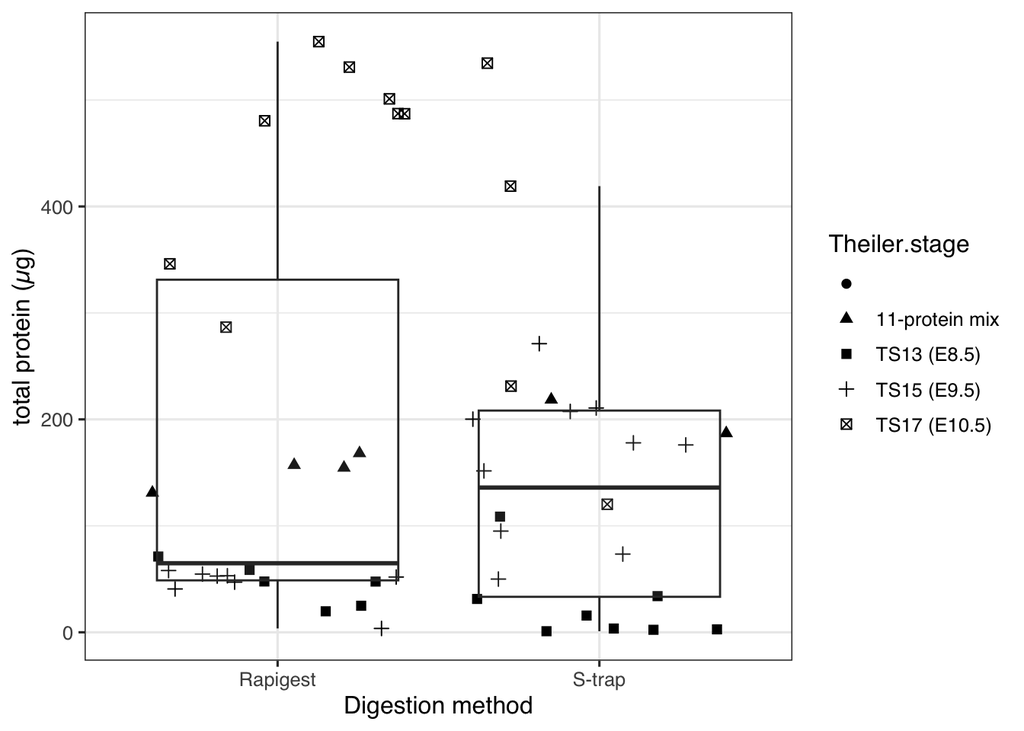

```r
emb.prot.plot.2 <- ggplot(data = emb.all, aes(x = digestion.method,
                                              y = total.protein),
                          fill = Theiler.stage)+
  geom_jitter(aes(shape = Theiler.stage),
              alpha = 2.0,
              size = 2)+
  geom_boxplot(outlier.shape = NA,
               alpha = 0.1)+
  xlab("Digestion method")+
  ylab("total protein (µg)")+
  scale_colour_discrete(na.translate = F)+
  theme_bw(base_size = 12, base_family = "Helvetica")+scale_fill_grey()

emb.prot.plot.2
```

```r
emb9.5 <- read.csv("https://docs.google.com/spreadsheets/d/e/2PACX-1vSmVToNNXZJgAwEeA5L8peYS-wVDpgBlwUPZIrNR0vxWjzcZlV5ShLP1nHaV8Twwy07oC9Yu9xpDGlm/pub?gid=761795663&single=true&output=csv",header = T)

head(emb9.5)
```

```
##     sample sample.type average.concentration..mg.mL. total.protein..µg.
## 1 C57M15-2 E9.5 embryo                            <0                 NA
## 2 C57M15-3 E9.5 embryo                          1.73              51.90
## 3 C57M10-7 E9.5 embryo                         1.823              54.69
## 4 C57M10-8 E9.5 embryo                          0.12               3.60
## 5 C57M10-5 E9.5 embryo                          1.77              53.10
## 6 C57M10-6 E9.5 embryo                          1.57              47.10
##                                          notes
## 1 lost embryo during Bradford assay processing
## 2
## 3
## 4
## 5
## 6
```

Addendum for NB5-104-2023-10-12-1600h

I also needed to compare the protein concentrations of my total protein lysates from several months ago, which were mostly digested in Rapigest, urea, and TEAB buffer. I could quantify proteins using Bradford assay. As a reminder, even diluting protein 1:9 in TBS did not sufficiently dilute SDS to prevent interference in Bradford assay.

Therefore, I 1) tested 2 TS17 (E10.5) embryo samples digested using S-trap lysis buffer and 2) re-quantified my Rapigest-digested samples (TS13-TS17, 11-mix)

```r
bca.brad.comp <- read.csv("https://docs.google.com/spreadsheets/d/e/2PACX-1vTAzoKgpClrgZYWR7Vg-LE1UF1wyMSPUwvrfhCi3FXlmWwaYWdL-ZXCZ8uW1l7frPZV6vbpWKR85-Sq/pub?gid=0&single=true&output=csv",
                          header = T)

bca.brad.comp$sample.type<- as.factor(bca.brad.comp$sample.type)
bca.brad.comp$Theiler.stage<- as.factor(bca.brad.comp$Theiler.stage)
bca.brad.comp$digestion.method<- as.factor(bca.brad.comp$digestion.method)


head(bca.brad.comp)
```

```
##   sample.ID     sample.type digestion.method quantification.assay Theiler.stage
## 1     12B-4 C57BL/6J embryo           S-trap                  BCA  TS17 (E10.5)
## 2     12B-6 C57BL/6J embryo           S-trap                  BCA  TS17 (E10.5)
## 3      15-2 C57BL/6J embryo         Rapigest                  BCA
## 4      15-3 C57BL/6J embryo         Rapigest                  BCA   TS15 (E9.5)
## 5      26-1 C57BL/6J embryo         Rapigest                  BCA   TS13 (E8.5)
## 6      26-2 C57BL/6J embryo         Rapigest                  BCA   TS13 (E8.5)
##   concentration lysate.volume..µL. total.protein lysate.volume.removed..uL.
## 1         8.917                 47       419.099                          3
## 2        11.375                 47       534.625                          3
## 3            NA                 NA            NA                         NA
## 4         1.934                 30        58.020                          6
## 5         0.831                 30        24.930                          6
## 6         2.372                 30        71.160                          6
##   present.lysate.volume..uL.     notes
## 1                         44
## 2                         44
## 3                         NA no embryo
## 4                         24
## 5                         24
## 6                         24
```

```r
bca.brad.sum <- summarySE(bca.brad.comp, measurevar="total.protein",
                          groupvars=c("Theiler.stage"),na.rm = T)
quant_dig.sum <- summarySE(bca.brad.comp, measurevar = "total.protein",
                           groupvars = c("digestion.method","Theiler.stage"),
                           na.rm = T)
quant_dig.sum
```

```
##   digestion.method  Theiler.stage N total.protein         sd       se        ci
## 1         Rapigest                0           NaN         NA       NA        NA
## 2         Rapigest 11-protein mix 2       162.630   7.806459  5.52000  70.13825
## 3         Rapigest    TS13 (E8.5) 3        51.550  23.898918 13.79805  59.36820
## 4         Rapigest    TS15 (E9.5) 3        50.500   8.895864  5.13603  22.09855
## 5         Rapigest   TS17 (E10.5) 4       457.410 117.547195 58.77360 187.04382
## 6           S-trap 11-protein mix 1       186.966         NA       NA        NA
## 7           S-trap   TS17 (E10.5) 2       476.862  81.689218 57.76300 733.94850
```

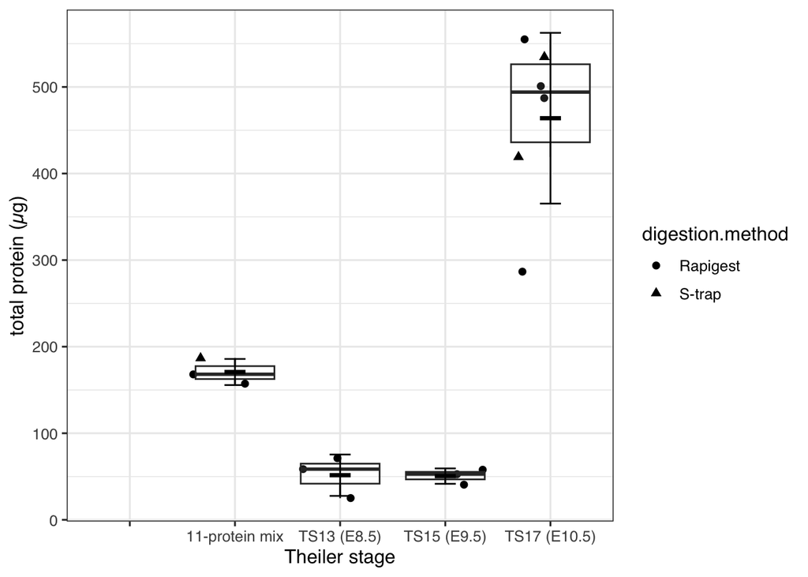

```r
library(ggplot2)

bca.brad.plot <- ggplot(data = bca.brad.comp, aes(x = Theiler.stage,
                                                  y = total.protein),
                        fill = digestion.method)+
  geom_jitter(aes(shape = digestion.method),
              alpha = 2.0,
              size = 2)+
  geom_boxplot(outlier.shape = NA,
               alpha = 0.1)+
  stat_summary(fun = mean, color = "black", position = position_dodge(0.75),width = 0.2,
               geom = "crossbar",
               show.legend = FALSE)+
  geom_errorbar(data = bca.brad.sum, aes(ymin=total.protein-sd,
                                         ymax=total.protein+sd),
                width=.2,
                position=position_dodge(0.75))+
  xlab("Theiler stage")+
  ylab("total protein (µg)")+
  scale_colour_discrete(na.translate = F)+
  theme_bw(base_size = 12, base_family = "Helvetica")+scale_fill_grey()

bca.brad.plot
```